# Analyzing #first7jobs tweets with Monkeylearn and R

M. Salmon

August 25, 2016

Have you tweeted about your “#firstsevenjobs”? I did!

[figure not shown]

“#firstsevenjobs” and “#first7jobs” tweets initial goal was to provide a short description of the 7 first activities they were paid for. It was quite fun to read them in my timeline! Of course the hashtag was also used by spammers, for making jokes, and for advertising for analyses in R, so not all the tweets contain the 7 descriptions.

However, I am confident quite a lot of “#firstsevenjobs” and “#first7jobs” actually describe first jobs, so I decided to use them as example of text analysis in R, starting from querying Twitter API with the rtweet package, then cleaning the tweets a bit, and then using the monkeylearn package to classify the jobs in an industry.

# Getting the tweets

I used the [`rtweet` R package](https://github.com/mkearney/rtweet/) for getting tweets via the Twitter API, searching for both “#firstsevenjobs” and “#first7jobs” hashtags and then keeping only unique non-retweeted tweets. I got 4858 tweets. This does not mean there were only that few tweets produced with the hashtags, but the Twitter API does not output aaall the tweets. You’d have to pay for it. But hey that’s a good number of tweets to start with, so I won’t complain. Here is part of the table I got:

| created_at | status_id | retweet_count | favorite_count | text | in_reply_to_status_id | in_reply_to_user_id | is_quote_status | quoted_status_id | source | lang | user_id | user_mentions | hashtags | urls | is_retweet | retweet_status_id | place_name | country | long1 | long2 | long3 | long4 | lat1 | lat2 | lat3 | lat4 |
| --- | --- | --- | --- | --- | --- | --- | --- | --- | --- | --- | --- | --- | --- | --- | --- | --- | --- | --- | --- | --- | --- | --- | --- | --- | --- | --- |
| 1471279142 | 765226304073404416 | 0 | 0 | What Were Your #FirstSevenJobs?: #firstsevenjobsphotography salespot washerbartenderurban plann… https://t.co/wwGp8NCohG #Architectbiz | NA | NA | FALSE | NA | twitterfeed | en | 2614678806 | NA | FirstSevenJobs, firstsevenjobsphotography, Architectbiz | http://bit.ly/2bkfauU | FALSE | NA | NA | NA | NA | NA | NA | NA | NA | NA | NA | NA |
| 1471136869 | 764629565431947264 | 0 | 0 | The unexpected joys of #FirstSevenJobs https://t.co/wV8XeFVlv8 | NA | NA | FALSE | NA | Twitter Web Client | en | 72931673 | NA | FirstSevenJobs | http://www.theatlantic.com/business/archive/2016/08/first-seven-jobs-meme/495293/ | FALSE | NA | NA | NA | NA | NA | NA | NA | NA | NA | NA | NA |
| 1471011664 | 764104419185229824 | 1 | 1 | My piece on #firstsevenjobs https://t.co/Il3a2Wrm0I | NA | NA | FALSE | NA | Twitter Web Client | en | 23485648 | NA | firstsevenjobs | https://fee.org/articles/crunching-pigeon-bones-to-broiling-elephants-first-seven-jobs/ | FALSE | NA | NA | NA | NA | NA | NA | NA | NA | NA | NA | NA |
| 1471378527 | 765643154964025344 | 0 | 6 | #first7jobs: milkshake maker, national anthem singer, babysitter, phone bank caller, tutor, camp counselor, bartender (<- badly) | NA | NA | FALSE | NA | TweetDeck | en | 746055972 | NA | first7jobs | NA | FALSE | NA | NA | NA | NA | NA | NA | NA | NA | NA | NA | NA |
| 1471322335 | 765407468499374080 | 0 | 0 | @BenSPLATT Oh, I thought you were posting your #firstsevenjobs! | 765399866835144704 | 237047303 | FALSE | NA | Twitter Web Client | en | 79398368 | 237047303 | firstsevenjobs | NA | FALSE | NA | NA | NA | NA | NA | NA | NA | NA | NA | NA | NA |
| 1471543324 | 766334362447151104 | 0 | 1 | 13 Entrepreneurs and CEOs Share Their #First7Jobs #jobseekers #advice https://t.co/k1hhSFKznH | NA | NA | FALSE | NA | Hootsuite | en | 194437674 | NA | First7Jobs, jobseekers, advice | http://ow.ly/49Zw303fmmB | FALSE | NA | NA | NA | NA | NA | NA | NA | NA | NA | NA | NA |
| 1471057398 | 764296241698238468 | 0 | 0 | Babysitter, educational video actor, Little League umpire, sales clerk, archery instructor, security guard, audiobook narrator. #first7jobs | NA | NA | FALSE | NA | Twitter for Android | en | 166682143 | NA | first7jobs | NA | FALSE | NA | NA | NA | NA | NA | NA | NA | NA | NA | NA | NA |
| 1470955506 | 763868874211078144 | 0 | 0 | #firstsevenjobs 1. Landscaper 2. passenger train car attendant 3. Mail sorter at Post office 4. pt Evenings/weekends/cruiser/prod 1090 CHEC | NA | NA | FALSE | NA | Twitter for iPhone | en | 72968191 | NA | firstsevenjobs | NA | FALSE | NA | NA | NA | NA | NA | NA | NA | NA | NA | NA | NA |
| 1470968211 | 763922164655415296 | 0 | 0 | #firstsevenjobs fashion intern, retail sales, rec coordinator,receptionist, teacher, school administrator | NA | NA | FALSE | NA | Twitter for iPhone | en | 627516775 | NA | firstsevenjobs | NA | FALSE | NA | NA | NA | NA | NA | NA | NA | NA | NA | NA | NA |
| 1471535015 | 766299512205811712 | 0 | 1 | 1. Golf course kitchen 2. Whole foods 3. Dean and Deluca 4. Hyatt 5. Gotts 6. Hillstone 7. Cheesecake Factory #firstsevenjobs | NA | NA | FALSE | NA | Twitter for iPhone | en | 320526505 | NA | firstsevenjobs | NA | FALSE | NA | NA | NA | NA | NA | NA | NA | NA | NA | NA | NA |

So you see, part of them contains actual job descriptions, others don’t… I mean, even I polluted the hashtag for advertising my own analysis! Among those that do describe jobs, some use commas or new lines between descriptions, or number them, or simply use spaces… Therefore, parsing tweets for getting 7 job descriptions per tweet was a little challenge.

I counted the number of possible separators for finding which one I should probably use to cut the tweet into 7 part. This yielded tweets cut in several parts… sometimes less than 7, sometimes more. I could not parse tweets whose descriptions were separated only by spaces because words inside a description are separated by spaces too so I could not make the difference. Besides, some people have tweeted about less or more than 7 packages. For instance one tweet says I have not had seven jobs yet but so far…- Accounts Assistant- Executive PA- Social Media Lead,yoga instructor?#FirstSevenJobs“. I did my best to remove tweet parts that were something like”Here are my #firstsevenjobs“, in order to keep only the job descriptions. At the end I kept only the tweets that had exactly 7 parts.

Out of 4858 I got 1637 tweets, that is 11459 job descriptions. That is *a lot*. Here is an excerpt of the table:

| status_id | wordsgroup |
| --- | --- |
| 763505013675229193 | Shopping bag |
| 763505013675229193 | Shopping assistant |
| 763505013675229193 | Housekeeper |
| 763505013675229193 | Cashier at Empik |
| 763505013675229193 | Fast food worker |
| 763505013675229193 | Microsoft’s consultant |
| 763505013675229193 | Cashier at Sport shop |
| 763511170196135936 | Dish Pig |
| 763511170196135936 | Toy Packer |
| 763511170196135936 | Asian Chef |
| 763511170196135936 | Bike Fitter |
| 763511170196135936 | Bike Shop Dude |
| 763511170196135936 | Beard Grower |
| 763511170196135936 | Sports Therapist |
| 763512991731945472 | babysitter |
| 763512991731945472 | busperson |
| 763512991731945472 | camp counselor |
| 763512991731945472 | secretary/clerk |
| 763512991731945472 | graduate assistant |
| 763512991731945472 | college prof |
| 763512991731945472 | full time writer |

I decided to keep only job descriptions for which the probability given by the classifier was higher than 50%. This corresponds to 6801 job descriptions out of the initial 11459 job descriptions. Jobs for which we predicted a category with a probability higher than 0.5 are divided as follows among industries:

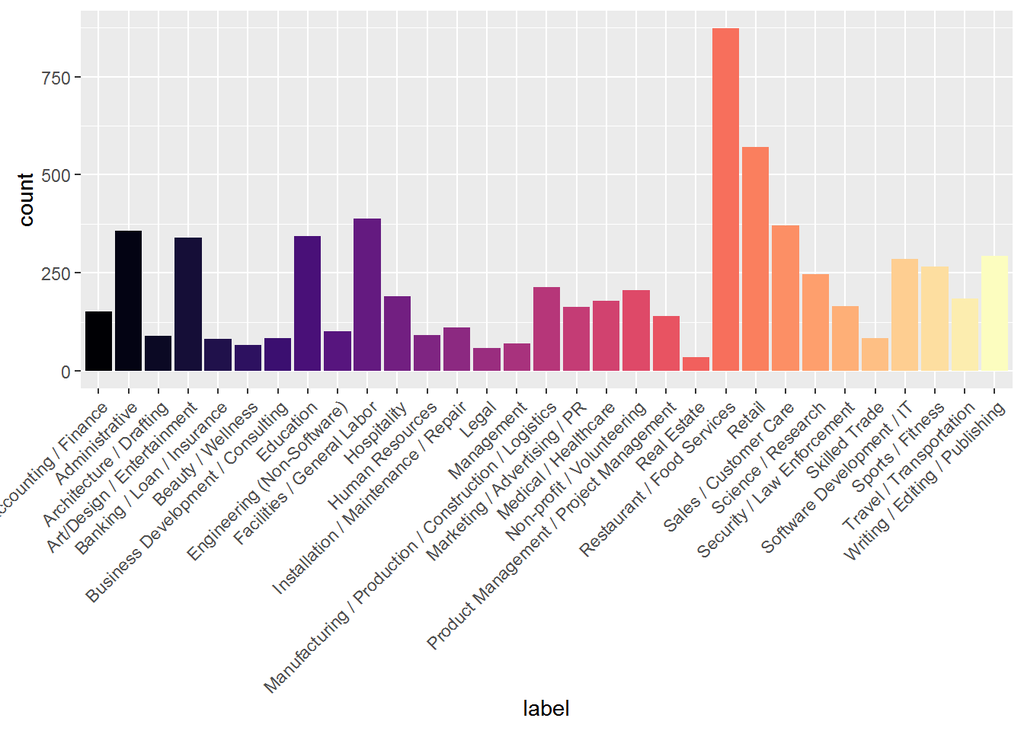

The most important categories are Restaurant/Food services and Retail. Usual first jobs?

Now let’s focus on exhaustive tweets only, id est tweets for which we could predict an industry for all 7 jobs with a probability higher than 50%.

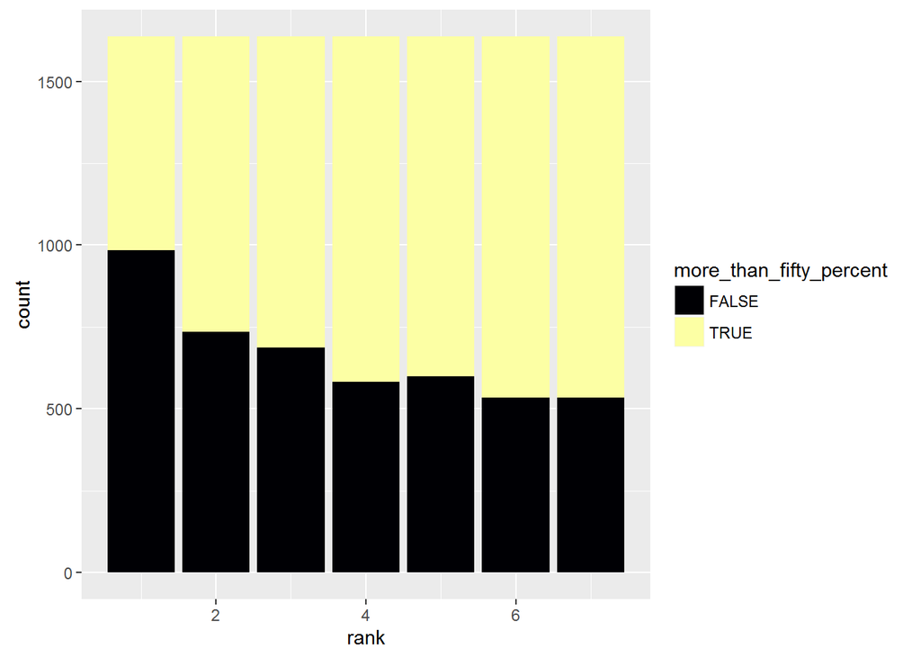

It seems to me that later job descriptions are easier to classify. Maybe because first jobs can be something like “Daddy’s knitting helper” or “Serial Lego builder” while later jobs are adult jobs?

Now let’s go back to tweets for which all industries could be predicted. As biased as it is, our sample of 95 tweets is still a nice playground for looking at life trajectories. For instance, are some categories rather first first jobs than late first jobs?

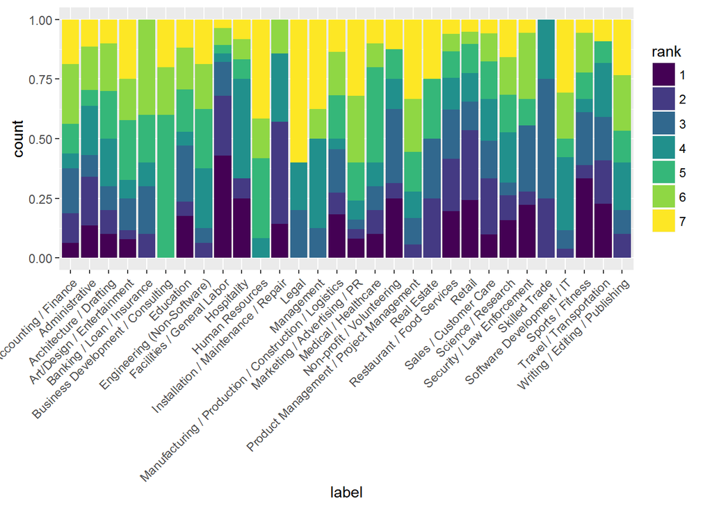

We can do the same graph for all job descriptions, even the ones in incompletely predicted tweets:

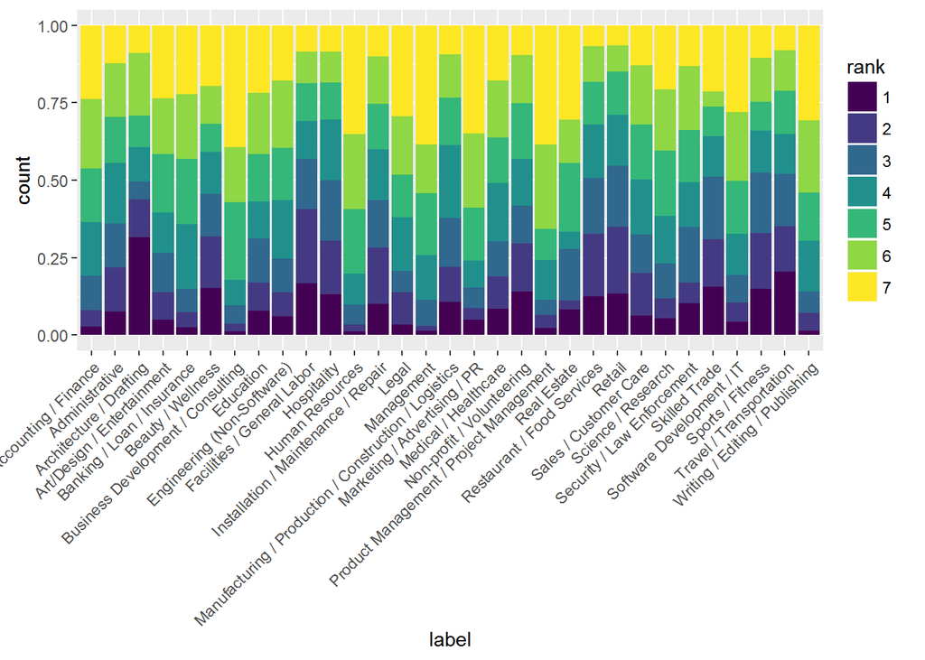

In both cases I’d tend to say that some industries such as Business Development / Consulting are not first-entry jobs, while Non-Profit / Volunteering are. Not a real surprise I guess?

I’ve said I wanted to look at life trajectories. This dataset won’t give me any information about the level of the job of course, e.g. whether you start as a clerk and end up leading your company, but I can look at how people move from one category to another. [My husband](https://twitter.com/damienaberlin) gave me a great idea of a circle graph he had seen in a newspaper. For this I used only tweets for which all 7 jobs could be predicted with a probability higher than 0.5.

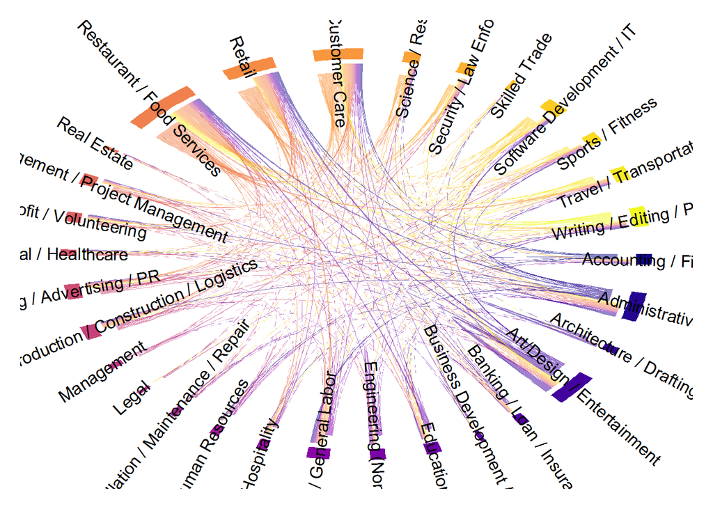

On this circle you see different industries, and the transition between them. [David Robinson](http://varianceexplained.org/) suggested I found the most common transitions and showed them in directed graphs but I’ll keep this idea for later, since this post is quite long already, ah!

Note that my whole code is [in this Github repo](https://github.com/masalmon/first_7_jobs). I used those R packages: rtweet, dplyr, tidyr, ggplot2, stringr, circlize and of course monkeylearn. Thanks a lot to their authors, and obviously thanks to people whose tweets I used… I might be a *little bit* more grateful to people who used separators and only posted 7 tweets. If you want to read another “#first7” analysis in R, I highly recommend [David Robinson’s post](http://varianceexplained.org/r/seven-fav-packages/) about the “7FavPackages” hashtag.